# Image Segment Attribution for Multi-Modal LLMs with Captum

In this tutorial, we demonstrate how to use Captum's `ImageMaskInput` to perform **image segment saliency analysis** on Multi-Modal Large Language Models (MM-LLMs). This allows us to understand which regions of an input image contribute most to the model's generated text response.

## What You'll Learn

- How to use `ImageMaskInput` to define interpretable image segments
- Two segmentation approaches:
  - **Grid-based segmentation**: Simple, uniform division of the image
  - **SAM-2 segmentation**: Semantically meaningful segments using Segment Anything Model 2
- How to apply `FeatureAblation` with `LLMAttribution` for MM-LLMs
- How to visualize attribution results as heatmaps

## Key Concepts

**Feature Ablation** works by systematically "masking out" (ablating) different image segments and measuring how the model's output changes. Segments that cause large changes when removed are considered more important for the model's prediction.

**ImageMaskInput** is Captum's adapter that:

1. Takes an image and segmentation mask
2. Converts it to an interpretable representation (presence/absence of each segment)
3. Handles the perturbation during attribution (replacing masked regions with a baseline color)

In this tutorial, we use **Google Gemma-4** as our multi-modal LLM, but the approach works with any vision-language model that follows the standard processor pattern.

# Step 1: Setup and Imports

First, let's import the necessary packages. We need:

- **PyTorch and Transformers**: For loading and running the MM-LLM model
- **Captum**: For attribution algorithms (`FeatureAblation`, `LLMAttribution`, `ImageMaskInput`)
- **PIL and Matplotlib**: For image handling and visualization
- **SAM-2**: For semantic image segmentation (Segment Anything Model 2)

```python
import warnings

warnings.filterwarnings("ignore")

from io import BytesIO

import numpy as np
import requests
import torch
import transformers


# Captum imports for attribution
from captum.attr import FeatureAblation
from captum.attr._core.llm_attr import LLMAttribution
from captum.attr._utils.interpretable_input import ImageMaskInput
from PIL import Image
from transformers import AutoModelForCausalLM, AutoProcessor

print(f"PyTorch version: {torch.__version__}")
print(f"CUDA available: {torch.cuda.is_available()}")
print(f"Transformers version: {transformers.__version__}")
```

```
PyTorch version: 2.12.0a0+fb
CUDA available: True
Transformers version: 5.5.0
```

# Step 2: Load the Multi-Modal LLM

The model can process both text and images, making it ideal for demonstrating image attribution in multi-modal contexts.

```python
# Model configuration
model_id = "google/gemma-4-31B-it"

# Load the model and processor
print("Loading processor...")
processor = AutoProcessor.from_pretrained(model_id)

print("Loading model with 4-bit quantization...")
model = AutoModelForCausalLM.from_pretrained(
    model_id,
    torch_dtype=torch.bfloat16,
    device_map="auto",
)

print(f"\nModel loaded successfully!")
print(f"Model device: {model.device}")
```

# Step 3: Load a Sample Image

Let's load a sample image that we'll use to demonstrate image attribution. We'll use a classic image of a Volkswagen Beetle car.

```
Image loaded successfully!
Image size: (640, 480) (width x height)
```

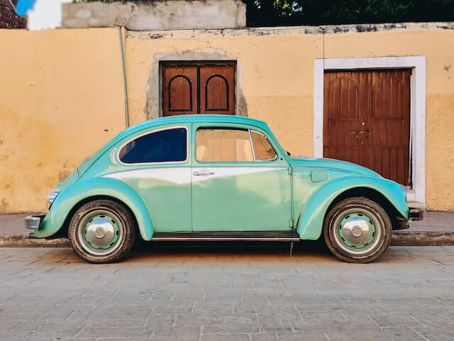

```python
def load_image_from_url(url):
    """Load an image from a URL."""
    response = requests.get(url)
    image = Image.open(BytesIO(response.content)).convert("RGB")
    return image


# Load a sample image from HuggingFace
image_url = "https://huggingface.co/datasets/huggingface/documentation-images/resolve/main/transformers/tasks/car.jpg"
image = load_image_from_url(image_url)

print(f"Image loaded successfully!")
print(f"Image size: {image.size} (width x height)")

# Display the image
image
```

# Step 4: Generate a Baseline Response

Before performing attribution, let's first see how the model responds to a simple image description prompt. This will help us understand what output we're trying to explain.

```python
# Define the conversation with image and text
messages = [
    {
        "role": "user",
        "content": [
            {"type": "image"},
            {"type": "text", "text": "Briefly describe the image in one sentence."},
        ],
    }
]

# Apply the chat template to format the prompt
prompt = processor.apply_chat_template(messages, add_generation_prompt=True)

# Process the inputs (image + text) for the model
inputs = processor(
    text=prompt,
    images=image,
    return_tensors="pt",
).to(model.device)

print("Input prepared successfully!")
print(f"Input token shape: {inputs['input_ids'].shape}")
```

```
Input prepared successfully!
Input token shape: torch.Size([1, 291])
```

```python
# Generate the model's response
print("Generating response...")

with torch.no_grad():
    output = model.generate(
        **inputs,
        max_new_tokens=512,
        do_sample=False,  # Greedy decoding for reproducibility
    )

# Decode only the generated tokens (exclude the input)
input_token_len = inputs["input_ids"].shape[1]
response = processor.decode(output[0][input_token_len:], skip_special_tokens=True)

print("\n" + "=" * 60)
print("Model Response:")
print("=" * 60)
print(response)
```

```
Generating response...

============================================================
Model Response:
============================================================
A light teal vintage Volkswagen Beetle is parked in profile against a yellow wall with two brown wooden doors.
```

# Step 5: Image Segmentation Methods

To use `ImageMaskInput` for attribution, we need to define how to segment the image into interpretable features. We'll demonstrate two approaches:

1. **Grid-based segmentation**: Simple, uniform division of the image into a grid
2. **SAM-2 segmentation**: Semantically meaningful segments using the Segment Anything Model 2

## Part A: Grid-Based Segmentation

The simplest approach is to divide the image into a uniform m×n grid. This is fast and requires no external models, but segments may not align with semantic boundaries.

```python
def create_grid_mask(image, rows, cols):
    """
    Create a grid mask that divides the image into rows x cols segments.

    Args:
        image: PIL Image
        rows: Number of rows in the grid
        cols: Number of columns in the grid

    Returns:
        Tensor of shape (height, width) with integer segment IDs
    """
    width, height = image.size
    mask = torch.zeros((height, width), dtype=torch.int32)

    h_step = height // rows
    w_step = width // cols

    for row in range(rows):
        for col in range(cols):
            # Calculate segment boundaries
            y_start = row * h_step
            y_end = height if row == rows - 1 else (row + 1) * h_step
            x_start = col * w_step
            x_end = width if col == cols - 1 else (col + 1) * w_step

            # Assign unique segment ID
            segment_id = row * cols + col
            mask[y_start:y_end, x_start:x_end] = segment_id

    return mask


# Create a 4x5 grid mask (20 segments)
grid_mask = create_grid_mask(image, rows=4, cols=5)
print(f"Grid mask shape: {grid_mask.shape}")
print(f"Number of segments: {len(torch.unique(grid_mask))}")
```

```
Grid mask shape: torch.Size([480, 640])
Number of segments: 20
```

### Visualizing the Segmentation

`ImageMaskInput` provides a convenient `plot_mask_overlay()` method to visualize segmentations. Here we create an `ImageMaskInput` object with a dummy processor function just to leverage this visualization utility - the actual attribution will use a proper processor function defined later.

> **Note:** The `processor_fn` parameter is required by `ImageMaskInput`, but for visualization purposes only, we can use a simple identity function (`lambda x: x`).

```
Grid segmentation (4 rows × 5 columns = 20 segments):
```

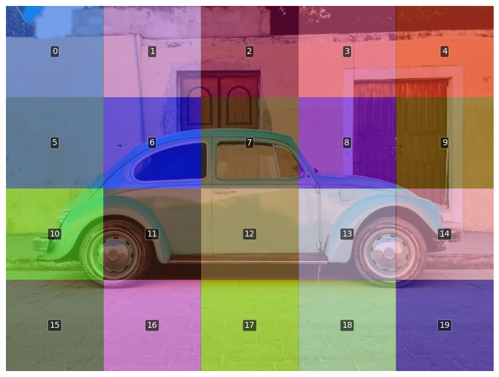

```python
# Create ImageMaskInput with grid mask for VISUALIZATION ONLY
# We use a dummy processor (identity function) since we just want to preview the segmentation
# The actual ImageMaskInput for attribution will be created later with a proper processor_fn
grid_input_preview = ImageMaskInput(
    image=image,
    mask=grid_mask,
    processor_fn=lambda x: x,  # Dummy processor - just for visualization
)

print("Grid segmentation (4 rows × 5 columns = 20 segments):")
grid_input_preview.plot_mask_overlay(show=True)
```

## Part B: SAM-2 Semantic Segmentation

For more semantically meaningful segments, we can use **SAM-2 (Segment Anything Model 2)** to automatically detect objects and regions in the image. SAM-2 produces masks that follow object boundaries, making the attribution results more interpretable.

```python
from transformers import pipeline

# Load SAM-2 for automatic mask generation
sam_generator = pipeline(
    "mask-generation", model="facebook/sam2-hiera-large", device=0
)

print("SAM-2 model loaded successfully!")
```

```python
# Generate semantic masks using SAM-2
# points_per_batch controls memory usage during mask generation
sam_outputs = sam_generator(image, points_per_batch=16)

# Extract the list of binary masks
sam_masks = sam_outputs["masks"]

print(f"SAM-2 generated {len(sam_masks)} semantic segments")
print(f"Each mask shape: {sam_masks[0].shape}")
```

```
SAM-2 generated 14 semantic segments
Each mask shape: torch.Size([480, 640])
```

```
SAM-2 segmentation (14 semantic segments):
```

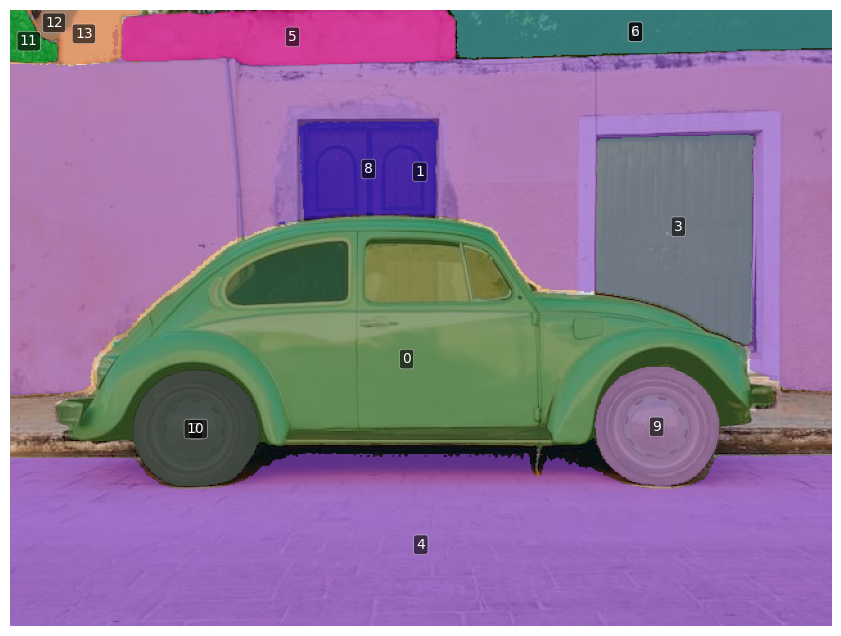

```python
# Similarly, create ImageMaskInput with SAM-2 masks for VISUALIZATION ONLY
# Notice how SAM-2 segments follow semantic boundaries (car body, windows, wheels, etc.)
sam_input_preview = ImageMaskInput(
    image=image,
    mask_list=sam_masks,
    processor_fn=lambda x: x,  # Dummy processor - just for visualization
)

print(f"SAM-2 segmentation ({len(sam_masks)} semantic segments):")
sam_input_preview.plot_mask_overlay(show=True)
```

# Step 6: Setup Captum Attribution

Now we'll set up Captum's attribution tools:

- **FeatureAblation**: The underlying perturbation-based attribution algorithm
- **LLMAttribution**: A wrapper that handles the complexities of LLM attribution (sequential token generation, probability aggregation, etc.)

```python
# Initialize FeatureAblation with the model
fa = FeatureAblation(model)

# Wrap it with LLMAttribution for handling LLM-specific complexities
llm_attr = LLMAttribution(fa, processor.tokenizer)

print("Attribution tools initialized!")
```

```
Attribution tools initialized!
```

# Step 7: Create ImageMaskInput for Attribution

The key component is the `processor_fn` - a function that converts an image into the model's expected input format. This function is called during attribution for each perturbed version of the image.

```python
def processor_fn(img):
    """
    Convert an image to model inputs.

    This function is called by ImageMaskInput for each perturbed image
    during the attribution process.

    Args:
        img: PIL Image (potentially with masked regions)

    Returns:
        Model inputs (tokenized text + processed image)
    """
    messages = [
        {
            "role": "user",
            "content": [
                {"type": "image"},
                {"type": "text", "text": "Briefly describe the image in one sentence."},
            ],
        }
    ]

    prompt = processor.apply_chat_template(messages, add_generation_prompt=True)

    return processor(
        text=prompt,
        images=img,
        return_tensors="pt",
    ).to(model.device)


print("Processor function defined!")
```

```
Processor function defined!
```

# Step 8: Run Attribution with SAM-2 Segmentation

Now we create an `ImageMaskInput` using the SAM-2 generated masks and run attribution. The `mask_list` parameter accepts a list of binary masks, which is exactly what SAM-2 provides.

```python
# Create ImageMaskInput with SAM-2 masks
sam_input = ImageMaskInput(
    image=image,
    mask_list=sam_masks,  # List of binary masks from SAM-2
    processor_fn=processor_fn,
)

print(f"Created ImageMaskInput with {sam_input.n_itp_features} interpretable features (segments)")

# Run attribution - this will ablate each segment and measure impact on output
print("\nRunning attribution (this may take a few minutes)...")
sam_attr_result = llm_attr.attribute(sam_input, forward_in_tokens=False)

print("Attribution complete!")
```

```
Created ImageMaskInput with 14 interpretable features (segments)

Running attribution (this may take a few minutes)...
Attribution complete!
```

# Step 9: Visualize Attribution Results

Now that attribution is complete, let's visualize the results to understand which image regions contributed to the model's response.

## Token-Level Attribution

The `plot_token_attr` method shows the attribution for each generated token. This helps us understand which image segments contributed to each word in the model's response:

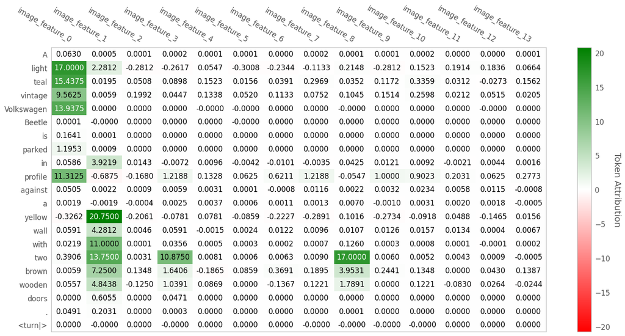

```python
# Plot token-level attribution
# This shows which segments are important for each generated token
sam_attr_result.plot_token_attr(show=True)
```

## Image Heatmap Visualization

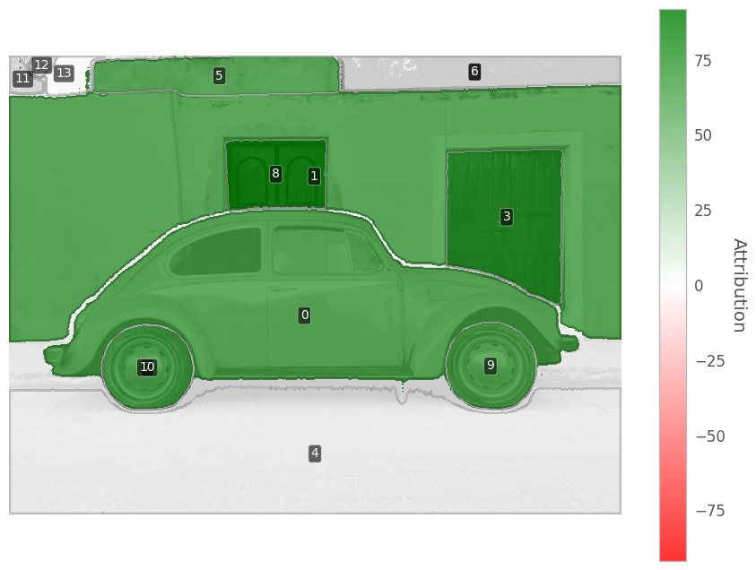

```python
# Plot overall image attribution heatmap
# This aggregates attribution across all generated tokens
sam_attr_result.plot_image_heatmap(show=True)
```

## Token-Specific Heatmaps

We can also visualize which image regions contributed to specific tokens in the response. Use `target_token_pos` to specify which token(s) to focus on.

This is useful for understanding *why* the model mentioned specific concepts in its description.

```python
# First, let's see which tokens were generated
print("Generated tokens:")
for i, token in enumerate(sam_attr_result.output_tokens):
    print(f"  Position {i}: '{token}'")
```

```
Generated tokens:
  Position 0: 'A'
  Position 1: 'light'
  Position 2: 'teal'
  Position 3: 'vintage'
  Position 4: 'Volkswagen'
  Position 5: 'Beetle'
  Position 6: 'is'
  Position 7: 'parked'
  Position 8: 'in'
  Position 9: 'profile'
  Position 10: 'against'
  Position 11: 'a'
  Position 12: 'yellow'
  Position 13: 'wall'
  Position 14: 'with'
  Position 15: 'two'
  Position 16: 'brown'
  Position 17: 'wooden'
  Position 18: 'doors'
  Position 19: '.'
  Position 20: '<turn|>'
```

```
Showing heatmap for tokens at positions (4, 6) ["Volkswagen Beetle"]
```

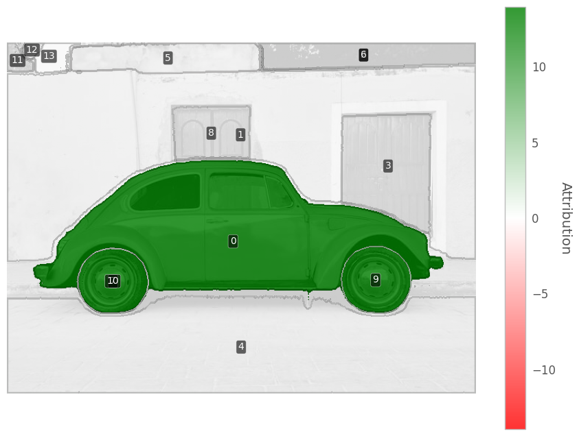

```python
# Example: Attribution heatmap for specific tokens
# Adjust the token positions based on the output above

# Heatmap for "Volkswagen Beetle" tokens
target_token_pos = (4, 6)
print(
    f'Showing heatmap for tokens at positions {target_token_pos} ["Volkswagen Beetle"]'
)
sam_attr_result.plot_image_heatmap(show=True, target_token_pos=target_token_pos)
```

```
Showing heatmap for tokens at positions (15, 19) ["two brown wooden doors"]
```

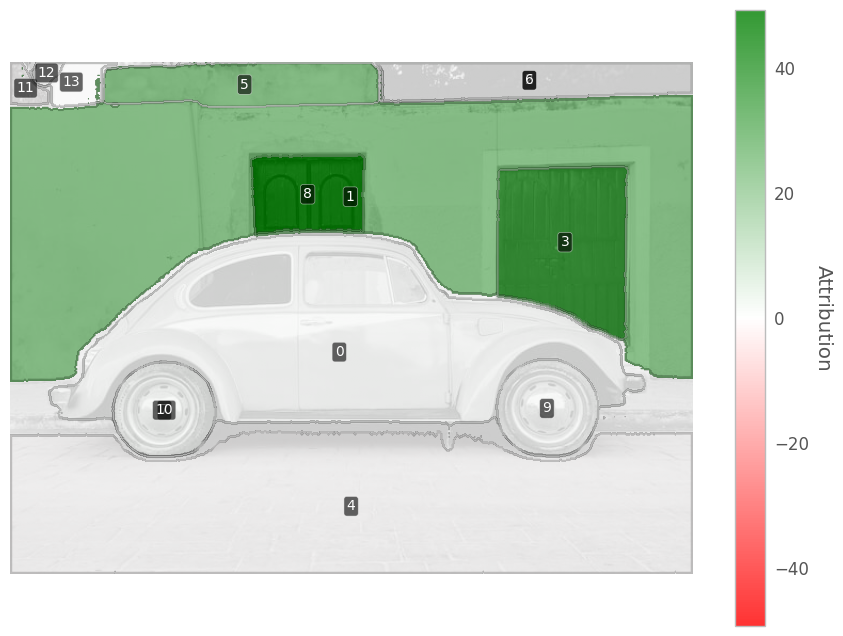

```python
# Heatmap for "two brown wooden doors" tokens (adjust positions as needed)
target_token_pos = (15, 19)
print(
    f'Showing heatmap for tokens at positions {target_token_pos} ["two brown wooden doors"]'
)
sam_attr_result.plot_image_heatmap(show=True, target_token_pos=target_token_pos)
```

# Step 10: Comparison - Grid-Based Attribution

For comparison, let's also run attribution using the simple grid-based segmentation. This is faster but may produce less interpretable results since grid cells don't follow object boundaries.

```
Running grid-based attribution with 20 segments...
Grid attribution complete!

Grid-based attribution heatmap:
```

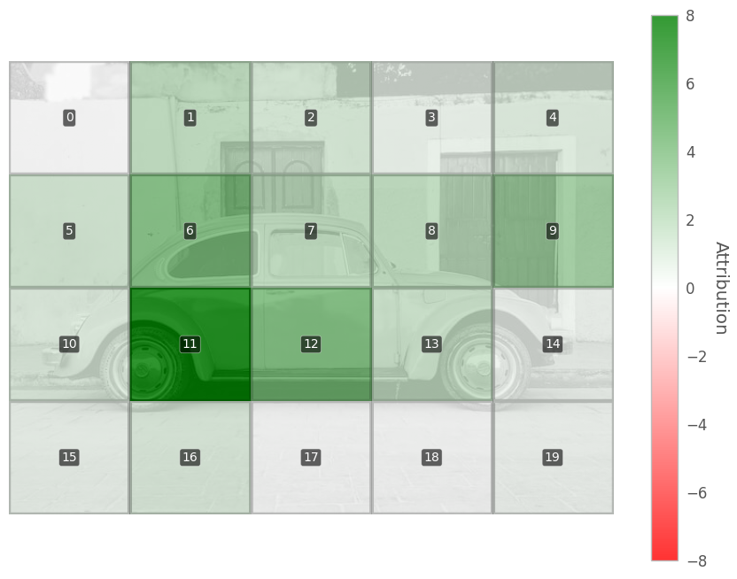

```python
# Create ImageMaskInput with grid mask for ATTRIBUTION (with proper processor_fn)
grid_input = ImageMaskInput(
    image=image,
    mask=grid_mask,
    processor_fn=processor_fn,  # Now using the real processor function
)

# Run attribution with grid-based segmentation
print(f"Running grid-based attribution with {grid_input.n_itp_features} segments...")
grid_attr_result = llm_attr.attribute(grid_input, forward_in_tokens=False)

print("Grid attribution complete!")

# Compare: visualize grid-based heatmap
print("\nGrid-based attribution heatmap:")
grid_attr_result.plot_image_heatmap(show=True)
```

# Conclusion

In this tutorial, we demonstrated how to use Captum's `ImageMaskInput` for image segment saliency analysis on multi-modal LLMs.

## Key Takeaways

1. **`ImageMaskInput`** provides a bridge between image segmentation and Captum's attribution algorithms, allowing you to understand which parts of an image influence a model's text output.
2. **Two segmentation approaches**:
   - **Grid-based**: Fast and simple, but segments don't follow semantic boundaries
   - **SAM-2**: Produces semantically meaningful segments that follow object boundaries, leading to more interpretable results
3. **Visualization options**:
   - `plot_mask_overlay()`: Visualize the segmentation
   - `plot_token_attr()`: See per-token attribution
   - `plot_image_heatmap()`: Overlay attribution on the image
   - `plot_image_heatmap(target_token_pos=...)`: Focus on specific tokens

## Next Steps

- Try different segmentation granularities (more/fewer grid cells, different SAM settings)
- Experiment with different prompts to see how image regions influence different types of responses
- Apply this technique to your own multi-modal models and use cases

## References

- [Captum Documentation](https://captum.ai)
- [LLM Attribution Paper](https://arxiv.org/abs/2312.05491)
- [Segment Anything Model 2](https://github.com/facebookresearch/segment-anything-2)

Download Tutorial Jupyter Notebook

Download Tutorial Source Code